# Automate all the things

JSM 2026 - Boston

Colin Rundel

Duke University

## Who am I

Assoc. Professor of the Practice, Dept. of Statistical Science, Duke University

- [Sta 523](https://sta523-fa25.github.io/) - Programming for Statistical Science R, 1st yr MS
- [Sta 323](https://sta323-sp26.github.io/) - Statistical Computing R, 2nd,3rd yr UG
- [Sta 663](https://sta663-sp26.github.io/) - Statistical Computing and Computation Python, 1st yr MS

All three courses run on GitHub - one (private) organization per course, students added as members, one repository per assignment per student or team.

~3,800 repositories (individual and team) over the last decade

## Click or script?

Myself and others have written a lot about why you should be using Git & GitHub for your courses.

Having adopted GitHub, you still have to decide how to manage things.

- Point-and-click is fine for small courses and tasks
- GitHub Classroom reduces the number of clicks (but doesn’t eliminate them) and constrains workflows
- Using the API is what makes things scale
  - one function call can iterate over an entire roster

GitHub classrooms has also gone away - sign-ups closed May 2026, decommissioned July 2026

## `ghclass`

An R package that wraps the GitHub REST and GraphQL APIs in class focused operations.

- `github_` - auth and account
- `org_` - membership, teams, repos
- `repo_` - files, collaborators, settings
- `team_` - teams within an org
- `user_` - GitHub accounts
- `issue_` - issues
- `pr_` / `branch_` - PRs and branches
- `action_` - runs, artifacts, badges
- `pages_` - GitHub Pages
- `local_repo_` - local git ops (clone, commit, …)

Functions are vectorized over a roster (data frame), API wrapped in `purrr::safely()`, and report success or failure per operation.

v0.4.1 on CRAN - workflow that follows is documented in the repo and a soon-to-be-submitted paper (JSDSE)

## Course as organization

One org per course per semester. Students added as *members* (to use teams). The default repository permission is set to `none`, so students only see their assigned repos.

```r
org_repos("ghclass-paper")
```

```
 [1] "ghclass-paper/.github"
 [2] "ghclass-paper/hw1"
 [3] "ghclass-paper/hw1-key"
 [4] "ghclass-paper/hw1_lab01_team01"
 [5] "ghclass-paper/hw1_lab01_team02"
 [6] "ghclass-paper/instructor"
 [7] "ghclass-paper/jsm26_lab01_team1"
 [8] "ghclass-paper/jsm26_lab01_team2"
 [9] "ghclass-paper/midterm1"
[10] "ghclass-paper/midterm1_ghclass-alice"
[11] "ghclass-paper/midterm1_ghclass-bob"
[12] "ghclass-paper/midterm1_ghclass-carol"
[13] "ghclass-paper/midterm1_ghclass-dave"
[14] "ghclass-paper/midterm1_ghclass-elizabeth"
[15] "ghclass-paper/midterm1_ghclass-fred"
```

- Templates repos (`hw1`, `midterm1`)
- Key repos (`hw1-key`)
- Student repos (`hw1_lab01_*`, `midterm1_ghclass-*`)
- Workflow details (`instructor`)

## 1. Setting up the course

Configure the organization *before* anyone is invited:

```r
org_set_repo_permission("ghclass-paper", "none")
```

```
✔ Set org "ghclass-paper"'s repo permissions to "none".
```

```r
org_set_workflow_permissions("ghclass-paper", "read")
```

```
✔ Set org "ghclass-paper"'s default workflow permissions to "read".
```

Check the org’s status with:

```r
org_sitrep("ghclass-paper")
```

```
── ghclass-paper sitrep: ───────────────────────────────────────────────────────
```

```
• Admins: "rundel"
```

```
• Members: 0
```

```
• Public repos: 13
```

```
• Private repos: 2
```

```
• Default repository permission: "none"
```

```
• Default workflow permissions: "read" <- Warning: this may prevent some GitHub
actions from working correctly.
```

```
• Members can create public repos: TRUE
```

```
• Members can create private repos: TRUE
```

```
• Members can fork private repos: FALSE
```

## Adding students

Collect student usernames via a web form / survey and validate before inviting:

```r
user_exists(c("rundel", "mine-cetinkaya-rundel", "ghclass-alice"))
```

```
[1]  TRUE  TRUE FALSE
```

Use ghclass to manage invites:

```r
need = setdiff(
  responded$github,
  c(org_members("ghclass-paper"), org_pending("ghclass-paper"))
)

org_invite("ghclass-paper", need)
```

The roster file is typically a join between LMS export and survey results

## 2.1 Assignments as repositories

- `hw1` - the source repo, holds the student scaffold and the CI config
- `hw1-key` - the answer key
- `hw1_lab01_team01`, … - one repo per team/individual, mirrored from the source

```r
repo_tree("ghclass-paper/hw1")
```

```
ghclass-paper/hw1
├─.github
│ └─workflows
│   └─check_assignment.yml
├─.gitignore
├─README.md
├─hw1.Rproj
└─hw1.qmd
```

```r
repo_tree("ghclass-paper/hw1-key")
```

```
ghclass-paper/hw1-key
├─.gitignore
├─README.md
└─hw1.qmd
```

## 2.2 Assigning teams

Per assignment we build a roster that tracks student details and random team assignments,

```r
roster = readr::read_csv("github_roster.csv", show_col_types = FALSE) |>
  team_roster(
    size = 3,
    by   = "section",
    name = "jsm26_lab{section}_team{team_id}",
    pad = 2,
    seed = 20250901
  )

roster |> dplyr::select(name, email, section, github, team)
```

```
# A tibble: 6 × 5
  name      email                 section github            team
  <chr>     <chr>                 <chr>   <chr>             <chr>
1 Alice     alice@example.edu     01      ghclass-alice     jsm26_lab01_team02
2 Bob       bob@example.edu       01      ghclass-bob       jsm26_lab01_team02
3 Carol     carol@example.edu     01      ghclass-carol     jsm26_lab01_team01
4 Dave      dave@example.edu      01      ghclass-dave      jsm26_lab01_team01
5 Elizabeth elizabeth@example.edu 01      ghclass-elizabeth jsm26_lab01_team02
6 Fred      fred@example.edu      01      ghclass-fred      jsm26_lab01_team01
```

Teams are just a column in the roster - these can also be manual created

## 2.3 Distributing an assignment

Make sure the source repo is a *template*,

```r
repo_set_template("ghclass-paper/hw1")
```

```
✔ Changed the template status of repo "ghclass-paper/hw1" to TRUE.
```

then create student repos from it,

```r
org_create_assignment(
  org         = "ghclass-paper",
  repo        = roster$team,
  user        = rep("rundel", nrow(roster)),
  team        = roster$team,
  source_repo = "ghclass-paper/hw1",
  add_badges  = TRUE
)
```

```
✔ Mirrored repo "ghclass-paper/hw1" to repo "ghclass-paper/jsm26_lab01_team02".
```

```
✔ Mirrored repo "ghclass-paper/hw1" to repo "ghclass-paper/jsm26_lab01_team01".
```

```
✔ Created team "jsm26_lab01_team02" in org "ghclass-paper".
```

```
✔ Created team "jsm26_lab01_team01" in org "ghclass-paper".
```

```
✔ Added user "rundel" to team "jsm26_lab01_team02".
```

```
✔ Added user "rundel" to team "jsm26_lab01_team01".
```

```
✔ Team "jsm26_lab01_team02" given "push" access to repo "ghclass-paper/jsm26_lab01_team02"
```

```
✔ Team "jsm26_lab01_team01" given "push" access to repo "ghclass-paper/jsm26_lab01_team01"
```

```
✔ Modified file "ghclass-paper/jsm26_lab01_team01/README.md".
```

```
✔ Modified file "ghclass-paper/jsm26_lab01_team02/README.md".
```

Individual assignments are created with the same function, just without the `team` argument

## 3.1 Live assignments

While an assignment is open, student work is queryable and assignments can be edited / corrected,

```r
repos = org_repos("sta523-fa25", "hw01_")
```

```r
repo_n_commits(repos)
```

```
# A tibble: 12 × 3
   repo                          branch     n
   <chr>                         <chr>  <int>
 1 sta523-fa25/hw01_lab01_team01 main      41
 2 sta523-fa25/hw01_lab01_team02 main      14
 3 sta523-fa25/hw01_lab01_team03 main      75
 4 sta523-fa25/hw01_lab01_team04 main      49
 5 sta523-fa25/hw01_lab01_team05 main      30
 6 sta523-fa25/hw01_lab01_team06 main      20
 7 sta523-fa25/hw01_lab01_team07 main      35
 8 sta523-fa25/hw01_lab01_team08 main      50
 9 sta523-fa25/hw01_lab01_team09 main      27
10 sta523-fa25/hw01_lab02_team01 main      23
11 sta523-fa25/hw01_lab02_team02 main      11
12 sta523-fa25/hw01_lab02_team03 main      13
```

```r
repo_add_file(
  repos,
  file = "late_addition.csv",
  repo_folder = "data"
)
```

```r
repo_modify_file(
  repos, path = "README.md",
  pattern = "Due: .*",
  content = "Due: 2026-09-22",
  method = "replace"
)
```

## 3.2 Automated feedback

GitHub Actions provide a powerful tool for automating a varierty of things,

- Our feedback usually focuses process not correctness (reproducibility)
- We include workflows in student repos (`.github/workflows/check_assignment.yml`) as part of the source repo
- The checks are mostly R functions from [`checklist`](https://github.com/rundel/checklist) - required files present, document renders, etc.
- Uses a prebuilt docker image - [`r_gh_action`](https://github.com/DukeStatSci/r_gh_actions)
- `add_badges = TRUE` at distribution put a pass / fail badge at the top of each README

## `.github/workflows/check_assignment.yml`

```yaml
on: push
name: Check Assignment
jobs:
  check-allowed-files:
    runs-on: ubuntu-latest
    container:
      image: ghcr.io/dukestatsci/r_gh_actions:latest
    steps:
    - name: Checkout
      uses: actions/checkout@v7
    - name: Check Files
      run: |
        checklist::quit_on_failure({
          checklist::check_allowed_files(
            c("hw1.qmd", "hw1.Rproj", "README.md", "data/*")
          )
        })
      shell: Rscript {0}
  check-renders:
    runs-on: ubuntu-latest
    container:
      image: ghcr.io/dukestatsci/r_gh_actions:latest
    steps:
    - name: Checkout
      uses: actions/checkout@v7
    - name: Check Renders
      run: |
        checklist::check_qmd_renders("hw1.qmd", install_missing = TRUE)
      shell: Rscript {0}
    - name: Create artifacts
      uses: actions/upload-artifact@v7
      with:
        name: hw1-html
        path: hw1.html
```

## What students see

[figure not shown]

[figure not shown]

[figure not shown]

[figure not shown]

[figure not shown]

[figure not shown]

## 4.1 Collecting assignments

After the due date, clone every repo, downloads CI artifacts, and scaffolds comment markdown files.

```r
org_grade_assignment(
  "hw1", "ghclass-paper", "jsm26_",
  key_repo = "ghclass-paper/hw1-key",
  comment_template = "## hw1 feedback\n\n"
)
```

```
ℹ Cloning 2 student repos matching "jsm26_".
```

```
✔ Cloned "ghclass-paper/jsm26_lab01_team1".
```

```
✔ Cloned "ghclass-paper/jsm26_lab01_team2".
```

```
ℹ Creating comment files.
```

```
✔ Created 2 comment files in 'hw1/comments'.
```

```
ℹ Cloning key repo "ghclass-paper/hw1-key".
```

```
✔ Cloned "ghclass-paper/hw1-key".
```

```r
fs::dir_tree("hw1")
```

```
hw1
├── comments
│   ├── jsm26_lab01_team1.md
│   └── jsm26_lab01_team2.md
├── hw1-key
│   ├── README.md
│   └── hw1.qmd
└── repos
    ├── jsm26_lab01_team1
    │   ├── README.md
    │   ├── hw1.Rproj
    │   └── hw1.qmd
    └── jsm26_lab01_team2
        ├── README.md
        ├── hw1.Rproj
        └── hw1.qmd
```

`artifacts = c(html = "hw1-html")` also pulls down each repo’s rendered CI output

## 4.2 Scores & feedback

Numeric scores go to the gradebook,

```r
scores = readr::read_csv("hw1/scores.csv")
upload = dplyr::left_join(roster, scores, by = "team")

stopifnot(!any(is.na(upload$score)))

readr::write_csv(upload, "hw1/hw1_upload.csv")
```

Written feedback shared via GitHub issues,

```r
comments = fs::dir_ls("hw1/comments", glob = "*.md")
repos    = paste0("ghclass-paper/", fs::path_ext_remove(fs::path_file(comments)))

issue_create(repos, title = "hw1 feedback", body = purrr::map_chr(comments, readr::read_file))
```

```
✔ Created issue "hw1 feedback" for repo "ghclass-paper/jsm26_lab01_team1".
```

```
✔ Created issue "hw1 feedback" for repo "ghclass-paper/jsm26_lab01_team2".
```

## `markermd`

An interactive (Shiny) grading interface for Quarto and R Markdown assignments that works with `org_grade_assignment()`.

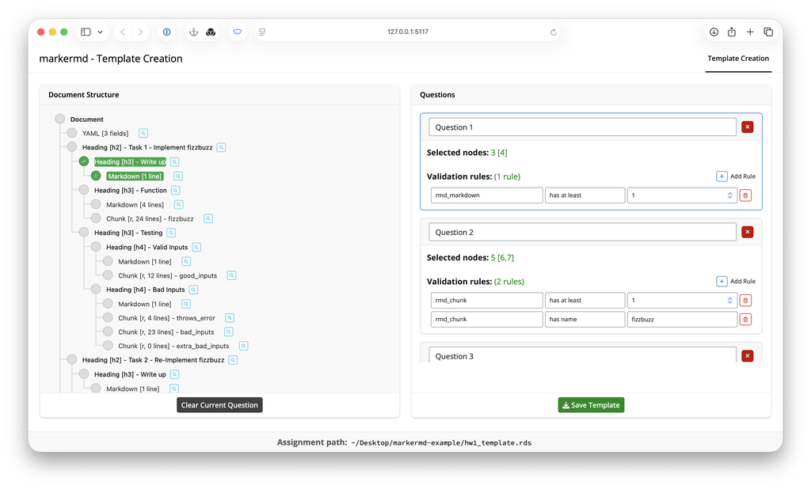

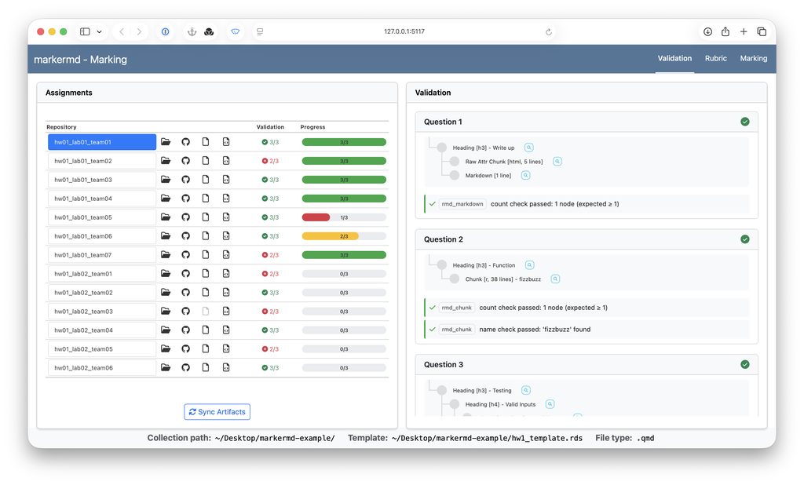

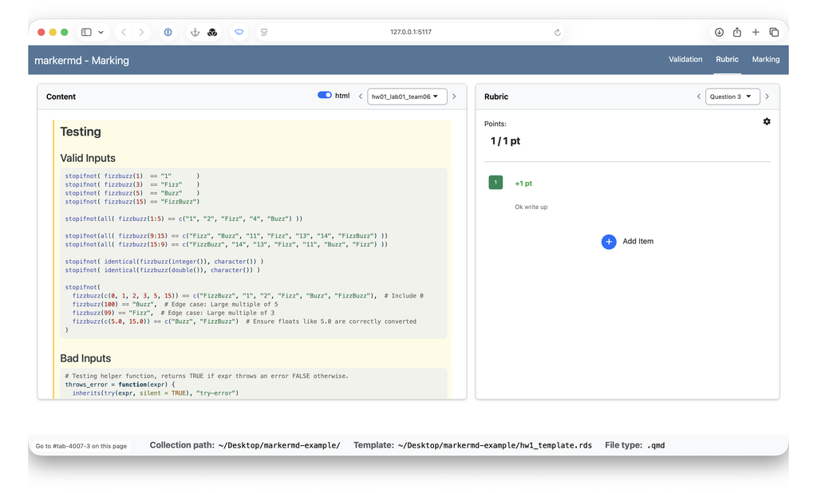

Built using [`q2r`](https://rundel.github.io/q2r) to parse and build the document tree shown above

## Using `markermd`

A grading project (folder) is initialized with `init_project()` which creates `.markermd/`.

Once initialized you can use:

- `template()` to build an assignment template - document subsections and validation rules
- `mark()` to validate submissions, build a rubric, and apply it across submissions
- `export_marks()` to collects results and populates `scores.csv` and `comments/`

We include some *very* experimental Claude code skills which can be used to help automate the tasks above

## Some advice

- Set `org_set_repo_permission()` and `org_set_workflow_permissions()` *before* anyone is invited, use `org_sitrep()` to check.
- Every org gets 2,000 Actions minutes / month free, 3,000 if using Team upgrade
  - easily exhausted for a medium-sized course - use self-host runners
- Artifacts expire after 90 days and count against org storage (500 MB free, 2 GB on Team) - just keep the latest
- Beware of secondary rate limits, e.g. bulk invitations and bulk issue creation
  - default cap of 50 invites/day
  - free Team upgrade via [GitHub Education](https://education.github.com) increases this
- Grading framework is well positioned for use with Agentic AI tools, but be aware of your schools data policies / FERPA / etc.
  - ghclass has initial support for “best effort” anonymization via `local_repo_anonymize()`

## Reach out

|  | rundel.github.io |
| --- | --- |
|  | [rundel](https://github.com/rundel/) |
|  | rundel@gmail.com colin.rundel@duke.edu |
|  | [rundel/ghclass](https://rundel.github.io/ghclass) rundel/checklist [rundel/q2r](https://rundel.github.io/q2r) [rundel/markermd](https://rundel.github.io/markermd) |
|  | github.com/ghclass-paper |